# HW 8

Stat 36-401

Due 11/14/2017

This homework is meant to introduce you to version control in R. It is an introduction, nothing more. You’ll also get a little practice with forwards & backwards model selection.

# 1. Getting git set up

### Make a new project

- New project is available under the R-studio `File` tab.
- Create a new directory: `LastName-HW8`
- Make sure you select the option in the dialog window to create a git repository.

### The `.gitignore` file.

Git is one type of version control, it’s the one that happens to be integrated with R-studio. (Convenient, because `github.com` is useful.) It’s going to track changes that you make to files in the repository directory.

But, while you want to track changes to your code, you don’t want to track every little bitty change to image files and whatnot. So you need to tell git to ignore certain files.

Open `.gitignore` (might not be visible in a directory window because the filename starts with `.`) from the files tab in R studio.

Add `.html`, `.pdf` and so on, to tell git to ignore those files.

### Create your `.rmd` file and put it in that directory.

### Find the `Git` tab in R studio.

It should be with the Environment and History windows.

Click on the checkbox next to your `.rmd` file to “stage” your changes. In this case, the change is adding the file to be tracked by git.

### Commit your change

The commit button should be near the top of this tab. And will open a new window.

The new window will highlight all changes (additions in green and deletions in red) so you can review them.

When you’re done reviewing, add a commit message describing what changes you’ve made “Initial commit” is the standard first commit message.

Then hit the `Commit` button.

### Actually use it.

As you work through the stepwise regression problem below, make additional commits. Any time you realize, “oh I should go back and fix…” it’s a good idea to make a commit before you start making those changes that you’ll need to propogate throughout. That way you can go back and undo it if you screw something up.

### What to turn in:

- When you’re done zip up the git repo that you’ve been working in and submit it.
- When we open the git history, I want to see at least 3 separate commits with meaningful messages.
- The `.html` file should be in the directory, but git should not be tracking it.

# 2. Stepwise model selection

(You have all the code here, so this should be straightforward.)

Information on these variables is available in the package documentation. We want to predict # of applications received using other variables in the dataset.

```r
library(ISLR)
data('College', package = 'ISLR')
str(College)
```

```
## 'data.frame':    777 obs. of  18 variables:
##  $ Private    : Factor w/ 2 levels "No","Yes": 2 2 2 2 2 2 2 2 2 2 ...
##  $ Apps       : num  1660 2186 1428 417 193 ...
##  $ Accept     : num  1232 1924 1097 349 146 ...
##  $ Enroll     : num  721 512 336 137 55 158 103 489 227 172 ...
##  $ Top10perc  : num  23 16 22 60 16 38 17 37 30 21 ...
##  $ Top25perc  : num  52 29 50 89 44 62 45 68 63 44 ...
##  $ F.Undergrad: num  2885 2683 1036 510 249 ...
##  $ P.Undergrad: num  537 1227 99 63 869 ...
##  $ Outstate   : num  7440 12280 11250 12960 7560 ...
##  $ Room.Board : num  3300 6450 3750 5450 4120 ...
##  $ Books      : num  450 750 400 450 800 500 500 450 300 660 ...
##  $ Personal   : num  2200 1500 1165 875 1500 ...
##  $ PhD        : num  70 29 53 92 76 67 90 89 79 40 ...
##  $ Terminal   : num  78 30 66 97 72 73 93 100 84 41 ...
##  $ S.F.Ratio  : num  18.1 12.2 12.9 7.7 11.9 9.4 11.5 13.7 11.3 11.5 ...
##  $ perc.alumni: num  12 16 30 37 2 11 26 37 23 15 ...
##  $ Expend     : num  7041 10527 8735 19016 10922 ...
##  $ Grad.Rate  : num  60 56 54 59 15 55 63 73 80 52 ...
```

### a. Set up the scope of the search:

```r
full_mod_string = paste('Apps~',  paste(names(College)[-2], collapse = ' + '), collapse = '')

mods = list(lower = as.formula('Apps~1'),
            upper = as.formula( full_mod_string)
)

mod.null = lm(mods$lower, data=College)
mod.full = lm(mods$upper, data=College)
```

Write out the models being fit here.

**The models being fit are with `Apps` as a response and `Private`, `Accept`, `Enroll`, `Top10perc`, `Top25perc`, `F.Undergrad`, `P.Undergrad`, `Outstate`, `Room.Board`, `Books`, `Personal`, `PhD`, `Terminal`, `S.F.Ratio`, `perc.alumni`, `Expend`, and `Grad.Rate` as the predictors. The full model includes all of these variables whereas the null model includes only the response.**

### b. Forward

```r
mod.forward = step(mod.null, scope=mods, direction='forward')
```

```
## Start:  AIC=12838.69
## Apps ~ 1
##
##               Df  Sum of Sq        RSS   AIC
## + Accept       1 1.0346e+10 1.2774e+09 11125
## + Enroll       1 8.3351e+09 3.2881e+09 11860
## + F.Undergrad  1 7.7108e+09 3.9125e+09 11995
## + Private      1 2.1701e+09 9.4531e+09 12680
## + P.Undergrad  1 1.8436e+09 9.7797e+09 12706
## + PhD          1 1.7742e+09 9.8491e+09 12712
## + Terminal     1 1.5869e+09 1.0036e+10 12727
## + Top25perc    1 1.4372e+09 1.0186e+10 12738
## + Top10perc    1 1.3344e+09 1.0289e+10 12746
## + Expend       1 7.8327e+08 1.0840e+10 12786
## + Personal     1 3.7130e+08 1.1252e+10 12816
## + Room.Board   1 3.1621e+08 1.1307e+10 12819
## + Grad.Rate    1 2.5033e+08 1.1373e+10 12824
## + Books        1 2.0424e+08 1.1419e+10 12827
## + S.F.Ratio    1 1.0630e+08 1.1517e+10 12834
## + perc.alumni  1 9.4622e+07 1.1529e+10 12834
## <none>                      1.1623e+10 12839
## + Outstate     1 2.9243e+07 1.1594e+10 12839
##
## Step:  AIC=11124.94
## Apps ~ Accept
##
##               Df Sum of Sq        RSS   AIC
## + Top10perc    1 298543648  978867162 10920
## + Expend       1 237832439 1039578371 10967
## + Top25perc    1 172865433 1104545378 11014
## + Grad.Rate    1  80919712 1196491098 11076
## + Room.Board   1  73480089 1203930722 11081
## + Outstate     1  64480760 1212930051 11087
## + S.F.Ratio    1  59842954 1217567857 11090
## + perc.alumni  1  43974982 1233435829 11100
## + PhD          1  40339305 1237071506 11102
## + Terminal     1  34118294 1243292517 11106
## + Enroll       1  12102492 1265308319 11120
## + Books        1   7628546 1269782265 11122
## + F.Undergrad  1   5226771 1272184040 11124
```

[output cut: 171 more lines]

```
## + Personal     1    426703 827138766 10809
## + perc.alumni  1     39675 827525794 10810
## + Books        1     25040 827540429 10810
##
## Step:  AIC=10807.53
## Apps ~ Accept + Top10perc + Expend + Outstate + Enroll + Room.Board +
##     Top25perc + Private + PhD + Grad.Rate + F.Undergrad + P.Undergrad
##
##               Df Sum of Sq       RSS   AIC
## <none>                     825317242 10808
## + S.F.Ratio    1   1485954 823831288 10808
## + Terminal     1    513811 824803431 10809
## + Personal     1    227696 825089547 10809
## + perc.alumni  1     20671 825296571 10810
## + Books        1     13607 825303635 10810
```

```r
summary(mod.forward)
```

```
##
## Call:
## lm(formula = Apps ~ Accept + Top10perc + Expend + Outstate +
##     Enroll + Room.Board + Top25perc + Private + PhD + Grad.Rate +
##     F.Undergrad + P.Undergrad, data = College)
##
## Residuals:
##     Min      1Q  Median      3Q     Max
## -4931.0  -428.4   -28.0   325.6  7870.6
##
## Coefficients:
##               Estimate Std. Error t value Pr(>|t|)
## (Intercept) -157.28686  265.43114  -0.593 0.553643
## Accept         1.58691    0.04004  39.633  < 2e-16 ***
## Top10perc     50.41132    5.52514   9.124  < 2e-16 ***
## Expend         0.07247    0.01139   6.363 3.41e-10 ***
## Outstate      -0.09018    0.01831  -4.925 1.03e-06 ***
## Enroll        -0.88265    0.18468  -4.779 2.11e-06 ***
## Room.Board     0.14777    0.04695   3.147 0.001713 **
## Top25perc    -14.74735    4.41778  -3.338 0.000884 ***
## PrivateYes  -511.78760  134.28488  -3.811 0.000149 ***
## PhD          -10.70503    3.12107  -3.430 0.000636 ***
## Grad.Rate      8.63961    2.86106   3.020 0.002614 **
## F.Undergrad    0.05945    0.03244   1.833 0.067185 .
## P.Undergrad    0.04593    0.03184   1.443 0.149533
## ---
## Signif. codes:  0 '***' 0.001 '**' 0.01 '*' 0.05 '.' 0.1 ' ' 1
##
## Residual standard error: 1039 on 764 degrees of freedom
## Multiple R-squared:  0.929,  Adjusted R-squared:  0.9279
## F-statistic:   833 on 12 and 764 DF,  p-value: < 2.2e-16
```

Describe in words what is happening at each step of the search path.

**At each step of the search path, the search path is adding one more variable to the model based on the AIC. So, first, the path calculates the AIC of each variable not included in the model and orders them in ascending order. The next step will add the lowest AIC variable to the model, and then recalculate AICs with the new model. This is done until doing nothing has the lowest AIC.**

### c. Backward

```r
mod.backward = step(mod.full, scope=mods, direction='backward')
```

```
## Start:  AIC=10815.4
## Apps ~ Private + Accept + Enroll + Top10perc + Top25perc + F.Undergrad +
##     P.Undergrad + Outstate + Room.Board + Books + Personal +
##     PhD + Terminal + S.F.Ratio + perc.alumni + Expend + Grad.Rate
##
##               Df  Sum of Sq        RSS   AIC
## - perc.alumni  1       2057  823062005 10813
## - Books        1       8332  823068280 10813
## - Personal     1     263707  823323655 10814
## - Terminal     1     463415  823523363 10814
## - S.F.Ratio    1    1518247  824578195 10815
## - P.Undergrad  1    2073704  825133652 10815
## <none>                       823059948 10815
## - F.Undergrad  1    3337258  826397207 10816
## - PhD          1    3796560  826856508 10817
## - Grad.Rate    1    9368302  832428250 10822
## - Room.Board   1   10605426  833665374 10823
## - Top25perc    1   10951733  834011681 10824
## - Private      1   13942221  837002170 10826
## - Outstate     1   22020341  845080289 10834
## - Enroll       1   24321652  847381600 10836
## - Expend       1   43151679  866211628 10853
## - Top10perc    1   86866642  909926590 10891
## - Accept       1 1642984489 2466044437 11666
##
## Step:  AIC=10813.4
## Apps ~ Private + Accept + Enroll + Top10perc + Top25perc + F.Undergrad +
##     P.Undergrad + Outstate + Room.Board + Books + Personal +
##     PhD + Terminal + S.F.Ratio + Expend + Grad.Rate
##
##               Df  Sum of Sq        RSS   AIC
## - Books        1       7989  823069994 10811
## - Personal     1     261699  823323704 10812
## - Terminal     1     461438  823523443 10812
## - S.F.Ratio    1    1517299  824579304 10813
## - P.Undergrad  1    2071755  825133760 10813
## <none>                       823062005 10813
## - F.Undergrad  1    3335997  826398002 10814
## - PhD          1    3799154  826861159 10815
## - Grad.Rate    1    9830950  832892955 10821
```

[output cut: 78 more lines]

```
##
##               Df  Sum of Sq        RSS   AIC
## <none>                       825317242 10808
## - P.Undergrad  1    2248227  827565469 10808
## - F.Undergrad  1    3629713  828946955 10809
## - Grad.Rate    1    9850583  835167825 10815
## - Room.Board   1   10699017  836016260 10816
## - Top25perc    1   12037817  837355059 10817
## - PhD          1   12708568  838025810 10817
## - Private      1   15691081  841008323 10820
## - Enroll       1   24676722  849993965 10828
## - Outstate     1   26201946  851519188 10830
## - Expend       1   43734225  869051468 10846
## - Top10perc    1   89928332  915245574 10886
## - Accept       1 1696846612 2522163854 11674
```

```r
summary(mod.backward)
```

```
##
## Call:
## lm(formula = Apps ~ Private + Accept + Enroll + Top10perc + Top25perc +
##     F.Undergrad + P.Undergrad + Outstate + Room.Board + PhD +
##     Expend + Grad.Rate, data = College)
##
## Residuals:
##     Min      1Q  Median      3Q     Max
## -4931.0  -428.4   -28.0   325.6  7870.6
##
## Coefficients:
##               Estimate Std. Error t value Pr(>|t|)
## (Intercept) -157.28686  265.43114  -0.593 0.553643
## PrivateYes  -511.78760  134.28488  -3.811 0.000149 ***
## Accept         1.58691    0.04004  39.633  < 2e-16 ***
## Enroll        -0.88265    0.18468  -4.779 2.11e-06 ***
## Top10perc     50.41132    5.52514   9.124  < 2e-16 ***
## Top25perc    -14.74735    4.41778  -3.338 0.000884 ***
## F.Undergrad    0.05945    0.03244   1.833 0.067185 .
## P.Undergrad    0.04593    0.03184   1.443 0.149533
## Outstate      -0.09018    0.01831  -4.925 1.03e-06 ***
## Room.Board     0.14777    0.04695   3.147 0.001713 **
## PhD          -10.70503    3.12107  -3.430 0.000636 ***
## Expend         0.07247    0.01139   6.363 3.41e-10 ***
## Grad.Rate      8.63961    2.86106   3.020 0.002614 **
## ---
## Signif. codes:  0 '***' 0.001 '**' 0.01 '*' 0.05 '.' 0.1 ' ' 1
##
## Residual standard error: 1039 on 764 degrees of freedom
## Multiple R-squared:  0.929,  Adjusted R-squared:  0.9279
## F-statistic:   833 on 12 and 764 DF,  p-value: < 2.2e-16
```

Describe in words what is happening at each step of the search path.

**This search path is doing the opposie of the one above. It starts with the full model and at each step, the search path is removing one variable from the model based on the AIC. So, first, the path calculates the AIC of each variable included in the model and orders them in ascending order. The next step will remove the lowest AIC variable to the model, and then recalculate AICs with the new model. This is done until doing nothing has the lowest AIC.**

### d. Full Stepwise.

```r
mod.1 = lm(Apps ~ Private + Room.Board + Outstate, data = College)
mod.both = step(mod.1, scope=mods, direction='both')
```

```
## Start:  AIC=12531.93
## Apps ~ Private + Room.Board + Outstate
##
##               Df  Sum of Sq        RSS   AIC
## + Accept       1 6593536214 1.1782e+09 11068
## + Enroll       1 5041386231 2.7303e+09 11721
## + F.Undergrad  1 4608255422 3.1634e+09 11836
## + Top10perc    1  813334380 6.9584e+09 12448
## + Top25perc    1  716711525 7.0550e+09 12459
## + P.Undergrad  1  508910813 7.2628e+09 12481
## + Expend       1  428075863 7.3436e+09 12490
## + Grad.Rate    1  254273936 7.5174e+09 12508
## + PhD          1  231035722 7.5407e+09 12510
## + Terminal     1  161300984 7.6104e+09 12518
## + Personal     1  140355733 7.6313e+09 12520
## + Books        1   82156271 7.6895e+09 12526
## <none>                      7.7717e+09 12532
## + perc.alumni  1   17845612 7.7539e+09 12532
## + S.F.Ratio    1    3904684 7.7678e+09 12534
## - Room.Board   1  284204034 8.0559e+09 12558
## - Outstate     1  400907025 8.1726e+09 12569
## - Private      1 3467587469 1.1239e+10 12817
##
## Step:  AIC=11068.1
## Apps ~ Private + Room.Board + Outstate + Accept
##
##               Df  Sum of Sq        RSS   AIC
## + Top10perc    1  235140940  943026318 10897
## + Expend       1  167454800 1010712458 10951
## + Top25perc    1  106406267 1071760992 10996
## + Grad.Rate    1   30097378 1148069880 11050
## + S.F.Ratio    1   20101219 1158066039 11057
## + perc.alumni  1   11623881 1166543377 11062
## + Books        1    3838792 1174328466 11068
## + PhD          1    3109324 1175057935 11068
## <none>                      1178167258 11068
## + Enroll       1    1837978 1176329281 11069
## + P.Undergrad  1    1379900 1176787358 11069
## + Personal     1    1272292 1176894966 11069
## + Terminal     1     594909 1177572349 11070
```

[output cut: 182 more lines]

```
## - F.Undergrad  1    3629713  828946955 10809
## + Terminal     1     513811  824803431 10809
## + Personal     1     227696  825089547 10809
## + perc.alumni  1      20671  825296571 10810
## + Books        1      13607  825303635 10810
## - Grad.Rate    1    9850583  835167825 10815
## - Room.Board   1   10699017  836016260 10816
## - Top25perc    1   12037817  837355059 10817
## - PhD          1   12708568  838025810 10817
## - Private      1   15691081  841008323 10820
## - Enroll       1   24676722  849993965 10828
## - Outstate     1   26201946  851519188 10830
## - Expend       1   43734225  869051468 10846
## - Top10perc    1   89928332  915245574 10886
## - Accept       1 1696846612 2522163854 11674
```

```r
summary(mod.both)
```

```
##
## Call:
## lm(formula = Apps ~ Private + Room.Board + Outstate + Accept +
##     Top10perc + Expend + Enroll + PhD + Top25perc + Grad.Rate +
##     F.Undergrad + P.Undergrad, data = College)
##
## Residuals:
##     Min      1Q  Median      3Q     Max
## -4931.0  -428.4   -28.0   325.6  7870.6
##
## Coefficients:
##               Estimate Std. Error t value Pr(>|t|)
## (Intercept) -157.28686  265.43114  -0.593 0.553643
## PrivateYes  -511.78760  134.28488  -3.811 0.000149 ***
## Room.Board     0.14777    0.04695   3.147 0.001713 **
## Outstate      -0.09018    0.01831  -4.925 1.03e-06 ***
## Accept         1.58691    0.04004  39.633  < 2e-16 ***
## Top10perc     50.41132    5.52514   9.124  < 2e-16 ***
## Expend         0.07247    0.01139   6.363 3.41e-10 ***
## Enroll        -0.88265    0.18468  -4.779 2.11e-06 ***
## PhD          -10.70503    3.12107  -3.430 0.000636 ***
## Top25perc    -14.74735    4.41778  -3.338 0.000884 ***
## Grad.Rate      8.63961    2.86106   3.020 0.002614 **
## F.Undergrad    0.05945    0.03244   1.833 0.067185 .
## P.Undergrad    0.04593    0.03184   1.443 0.149533
## ---
## Signif. codes:  0 '***' 0.001 '**' 0.01 '*' 0.05 '.' 0.1 ' ' 1
##
## Residual standard error: 1039 on 764 degrees of freedom
## Multiple R-squared:  0.929,  Adjusted R-squared:  0.9279
## F-statistic:   833 on 12 and 764 DF,  p-value: < 2.2e-16
```

Describe in words what is happening at each step of the search path.

**This search path is a combination of the search paths from above. Starting with a model, the AIC is calculated for the variables in regards to either removal from the model for the variables in the model, or addition to the model for the variables not in the model. The variables are sorted in increasing order of their AICs so the variable with the lowest calculated AIC is either removed if it is in the model or added if it is not in the model. This is done until doing nothing has the lowest AIC.**

### e. Best Subsets

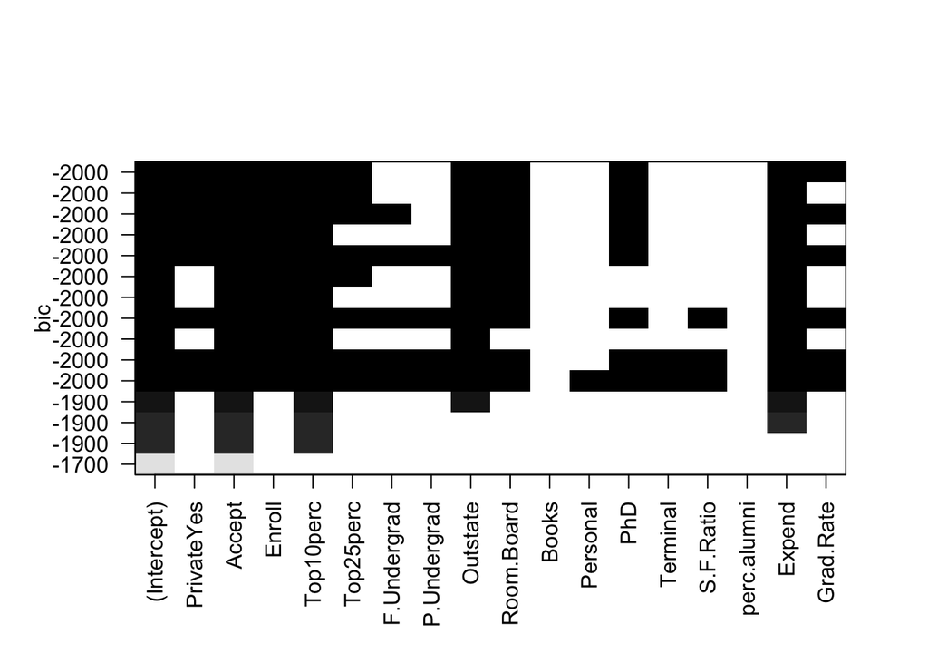

```r
library(leaps)
mod.best = regsubsets(mods$upper, data = College, nbest=1, nvmax = 15)
plot(mod.best)
```

```r
summary(mod.best)
```

```
## Subset selection object
## Call: regsubsets.formula(mods$upper, data = College, nbest = 1, nvmax = 15)
## 17 Variables  (and intercept)
##             Forced in Forced out
## PrivateYes      FALSE      FALSE
## Accept          FALSE      FALSE
## Enroll          FALSE      FALSE
## Top10perc       FALSE      FALSE
## Top25perc       FALSE      FALSE
## F.Undergrad     FALSE      FALSE
## P.Undergrad     FALSE      FALSE
## Outstate        FALSE      FALSE
## Room.Board      FALSE      FALSE
## Books           FALSE      FALSE
## Personal        FALSE      FALSE
## PhD             FALSE      FALSE
## Terminal        FALSE      FALSE
## S.F.Ratio       FALSE      FALSE
## perc.alumni     FALSE      FALSE
## Expend          FALSE      FALSE
## Grad.Rate       FALSE      FALSE
## 1 subsets of each size up to 15
## Selection Algorithm: exhaustive
##           PrivateYes Accept Enroll Top10perc Top25perc F.Undergrad
## 1  ( 1 )  " "        "*"    " "    " "       " "       " "
## 2  ( 1 )  " "        "*"    " "    "*"       " "       " "
## 3  ( 1 )  " "        "*"    " "    "*"       " "       " "
## 4  ( 1 )  " "        "*"    " "    "*"       " "       " "
## 5  ( 1 )  " "        "*"    "*"    "*"       " "       " "
## 6  ( 1 )  " "        "*"    "*"    "*"       " "       " "
## 7  ( 1 )  " "        "*"    "*"    "*"       "*"       " "
## 8  ( 1 )  "*"        "*"    "*"    "*"       " "       " "
## 9  ( 1 )  "*"        "*"    "*"    "*"       "*"       " "
## 10  ( 1 ) "*"        "*"    "*"    "*"       "*"       " "
## 11  ( 1 ) "*"        "*"    "*"    "*"       "*"       "*"
## 12  ( 1 ) "*"        "*"    "*"    "*"       "*"       "*"
## 13  ( 1 ) "*"        "*"    "*"    "*"       "*"       "*"
## 14  ( 1 ) "*"        "*"    "*"    "*"       "*"       "*"
## 15  ( 1 ) "*"        "*"    "*"    "*"       "*"       "*"
##           P.Undergrad Outstate Room.Board Books Personal PhD Terminal
```

[output cut: 16 more lines]

```
## 1  ( 1 )  " "       " "         " "    " "
## 2  ( 1 )  " "       " "         " "    " "
## 3  ( 1 )  " "       " "         "*"    " "
## 4  ( 1 )  " "       " "         "*"    " "
## 5  ( 1 )  " "       " "         "*"    " "
## 6  ( 1 )  " "       " "         "*"    " "
## 7  ( 1 )  " "       " "         "*"    " "
## 8  ( 1 )  " "       " "         "*"    " "
## 9  ( 1 )  " "       " "         "*"    " "
## 10  ( 1 ) " "       " "         "*"    "*"
## 11  ( 1 ) " "       " "         "*"    "*"
## 12  ( 1 ) " "       " "         "*"    "*"
## 13  ( 1 ) "*"       " "         "*"    "*"
## 14  ( 1 ) "*"       " "         "*"    "*"
## 15  ( 1 ) "*"       " "         "*"    "*"
```

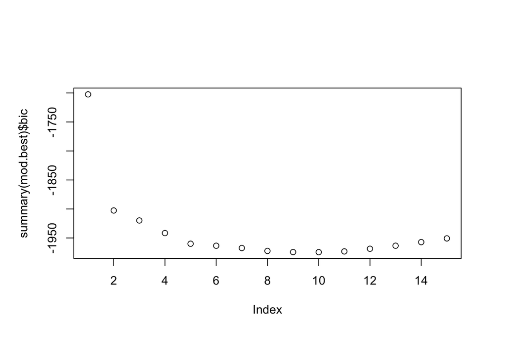

```r
plot(summary(mod.best)$bic)
```

```r
summary(mod.best)$which[summary(mod.best)$bic == min(summary(mod.best)$bic), ]
```

```
## (Intercept)  PrivateYes      Accept      Enroll   Top10perc   Top25perc
##        TRUE        TRUE        TRUE        TRUE        TRUE        TRUE
## F.Undergrad P.Undergrad    Outstate  Room.Board       Books    Personal
##       FALSE       FALSE        TRUE        TRUE       FALSE       FALSE
##         PhD    Terminal   S.F.Ratio perc.alumni      Expend   Grad.Rate
##        TRUE       FALSE       FALSE       FALSE        TRUE        TRUE
```

Describe the results. Use the documentation to help you.

**The function calculates the BIC for different combinations of subsets of the models. The first graph is showing the models and what BIC they have where the variables included in the model are shaded. The second summary is showing the optimal model based on the BIC calculations. The third graph plots the BIC calculations against the models from the subset function. Essentially, this function does the same search path method as the previous functions but uses BIC as the measurement.**

### f. Comparison

Compare the results from each of the searchs. In particular, do the results match? Why or why not? Will this happen for every data set? Why or why not? What did you learn from this exercise?

**The results do not match. The calculations for the first two searches use AIC whereas the last search uses BIC. BIC penalizes model complexity more than AIC, so it would make sense that the model found in the 2e. will be less complex than the models found in b., c., and d. The models in b., c., and d., however, are the same. This would happen because the searches are using the same calculation (AIC) to find the optimal model, so even though they are using different methods, they should still get the same results. This may not happen for every dataset because BIC and AIC have the same calculations aside from BIC penalizing complex models more heavily. These two will only differ if AIC chooses a larger model than BIC. From this exercise, I learned that there are a few different ways to figure out which model is optimal for linear regression. There are the backwards, forwards, and full stepwise calculations using AIC and also using BIC to find the optimal regression model.**

### g. `force.in`

Why is there a `force.in` option in regsubsets? When might you want to use this? How could you use `scope` in the `step` function to accomplish the same thing.

**The `force.in` option is included in regsubsets to specify columns that should be included in all models. This might be used when there is a specific variable that there is strong belief of being a strong predictor, or wanting to see how a specific variable interacts with all of the others for a regression model. The `scope` in the step function can be used to specify which variables will always be included by including the specific columns in the `lower` component of the `scope`.**